# Pertemuan 1 - Pemulusan

Yogi Nur Hamid

## Library

```r
library(forecast)
```

```r
library(graphics)
library(TTR)
library(TSA)
library(stats)
```

## Impor Data

```r
library(rio)
data <- import("https://raw.githubusercontent.com/yoginurhamid/MPDW/main/Data/Data%20Prak%201.xlsx")
data
```

```
##           Date Jumlah penumpang KRL Jabodetabek (Ribu jiwa)
## 1   2006-01-01                                         8681
## 2   2006-02-01                                         8144
## 3   2006-03-01                                         8920
## 4   2006-04-01                                         8462
## 5   2006-05-01                                         8899
## 6   2006-06-01                                         8606
## 7   2006-07-01                                         8787
## 8   2006-08-01                                         8661
## 9   2006-09-01                                         8829
## 10  2006-10-01                                         8767
## 11  2006-11-01                                         8895
## 12  2006-12-01                                         8774
## 13  2007-01-01                                         8723
## 14  2007-02-01                                         7566
```

[output cut: 196 more lines]

## Eksplorasi Data

Melihat data menggunakan fungsi `View()`, struktur data menggunakan fungsi `str()`, dan dimensi data menggunakan fungsi `dim()`.

```r
str(data)
```

```
## 'data.frame':    210 obs. of  2 variables:
##  $ Date                                        : POSIXct, format: "2006-01-01" "2006-02-01" ...
##  $ Jumlah penumpang KRL Jabodetabek (Ribu jiwa): chr  "8681" "8144" "8920" "8462" ...
```

```r
dim(data)
```

```
## [1] 210   2
```

Mengubah format Tanggal dan Jumlah

```r
data$Date <- as.Date(data$Date, format="%Y-%m-%d")
data$`Jumlah penumpang KRL Jabodetabek (Ribu jiwa)` <- as.numeric(data$`Jumlah penumpang KRL Jabodetabek (Ribu jiwa)`)
str(data$Date);str(data$`Jumlah penumpang KRL Jabodetabek (Ribu jiwa)`)
```

```
##  Date[1:210], format: "2006-01-01" "2006-02-01" "2006-03-01" "2006-04-01" "2006-05-01" ...
```

```
##  num [1:210] 8681 8144 8920 8462 8899 ...
```

Mengubah data agar terbaca sebagai data deret waktu dengan fungsi `ts()` .

```r
data.ts <- ts(data$`Jumlah penumpang KRL Jabodetabek (Ribu jiwa)`)
data.ts
```

```
## Time Series:
## Start = 1
## End = 210
## Frequency = 1
##   [1]  8681  8144  8920  8462  8899  8606  8787  8661  8829  8767  8895  8774
##  [13]  8723  7566  9009 10206 10608 10310 10761 10653 10446  9887 10031  9895
##  [25]  9868  9673 10469 10562 10582 10824 11206 11129 10481 10379 10583  9695
##  [37] 10686  9984 11185 10908 11448 11384 11348 10905 10243 11087 10592 10738
##  [49] 10541  9641 10759 10394 10476 10312 10466 10438  9685 10796 10106 10694
##  [61] 10354  9270 10733 10188 10513 10147 10749  9678  9692 10152  9852  9777
##  [73]  9779  9840 11285 11271 11872 12034 12391 11471 11556 11501 10650 10438
##  [85] 10089 10281 11240 11529 11767 11817 15407 14321 15113 15531 15487 15901
##  [97] 15176 14856 17471 16671 16781 17848 16585 17091 18253 19079 18605 20080
## [109] 19244 17640 21290 21171 22177 22207 21171 22295 22021 22964 22355 22996
## [121] 22238 21229 23206 23149 24401 23821 21574 23923 23570 24533 24104 24841
## [133] 24185 21743 25775 25411 27385 24432 27016 27679 26158 28765 28246 29059
## [145] 28075 25362 29223 28942 28995 24833 29086 28098 27618 29317 28049 29201
## [157] 27768 25305 28366 28062 28369 25816 29714 27651 28293 29278 28563 28860
## [169] 26733 25616 18548  5138  5077  8591 11116 11014  9678 10128 11622 11330
## [181] 10149  9796 12041 12452 12230 11978  5102  5947  8693 11347 12792 14213
## [193] 14484 10499 15735 15890 17075 18326 19467 19388 20587 21807 21589 23118
## [205] 22717 20811 23856 21402 23716 23292
```

Menampilkan ringkasan data

```r
summary(data.ts)
```

```
##    Min. 1st Qu.  Median    Mean 3rd Qu.    Max.
##    5077   10383   12006   16128   22627   29714
```

Membuat plot data deret waktu

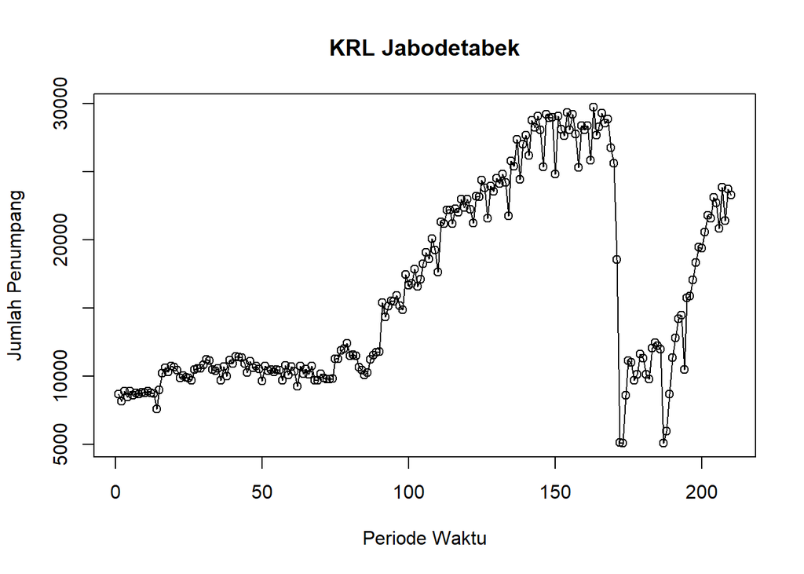

```r
ts.plot(data.ts, xlab="Periode Waktu", ylab="Jumlah Penumpang",
        main = "KRL Jabodetabek")
points(data.ts)
```

## Single Moving Average & Double Moving Average

### Pembagian Data

Pembagian data latih dan data uji dilakukan dengan perbandingan 80% data latih dan 20% data uji.

```r
#membagi data latih dan data uji
training_ma <- data[1:168,]
testing_ma <- data[169:210,]
train_ma.ts <- ts(training_ma$`Jumlah penumpang KRL Jabodetabek (Ribu jiwa)`)
test_ma.ts <- ts(testing_ma$`Jumlah penumpang KRL Jabodetabek (Ribu jiwa)`)
```

### Eksplorasi Data

Eksplorasi data dilakukan pada keseluruhan data, data latih serta data uji menggunakan plot data deret waktu.

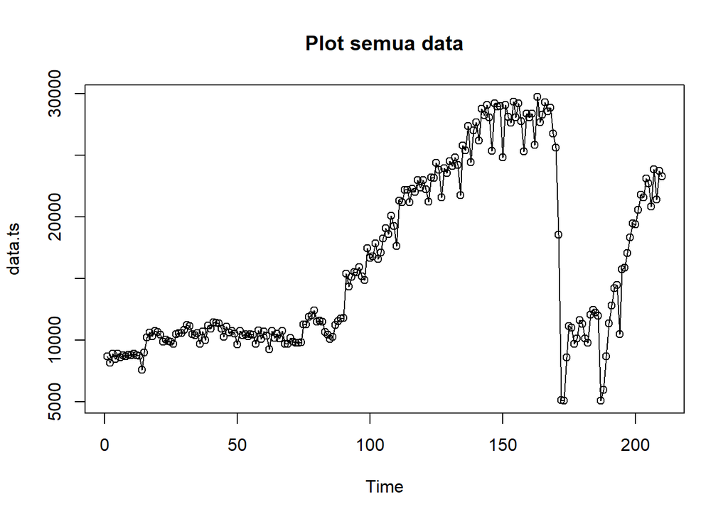

```r
#eksplorasi keseluruhan data
plot(data.ts, col="black",main="Plot semua data")
points(data.ts)
```

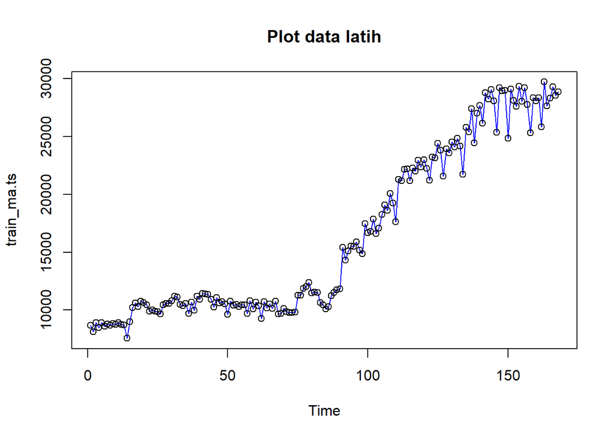

```r
#eksplorasi data latih
plot(train_ma.ts, col="blue",main="Plot data latih")
points(train_ma.ts)
```

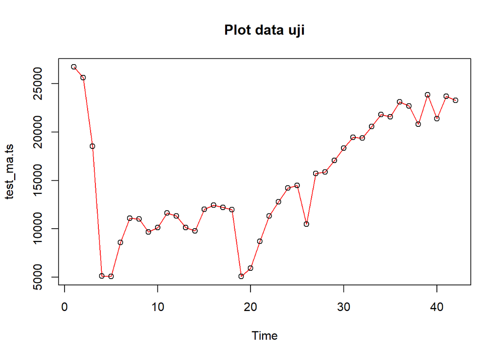

```r
#eksplorasi data uji
plot(test_ma.ts, col="red",main="Plot data uji")
points(test_ma.ts)
```

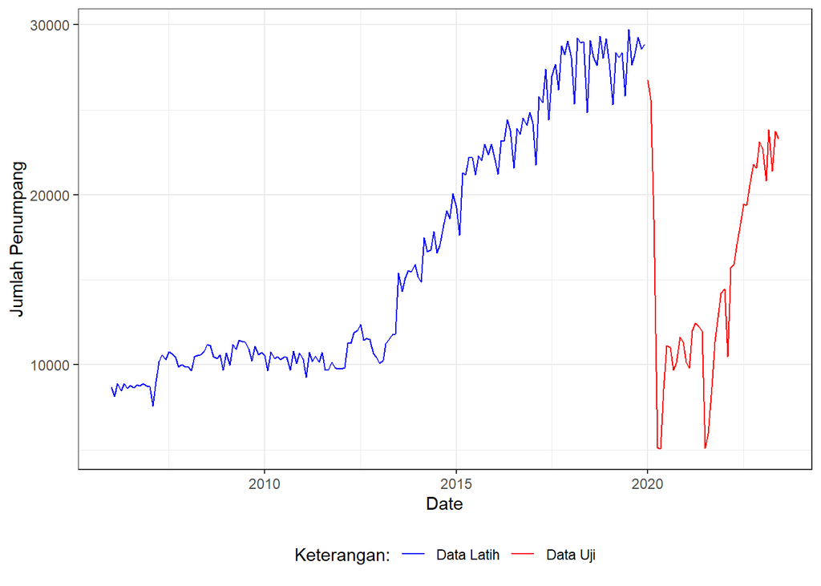

```r
#Membuat plot dengan GGPLOT
library(ggplot2)
ggplot() +
  geom_line(data = training_ma, aes(x = Date, y = `Jumlah penumpang KRL Jabodetabek (Ribu jiwa)`, col = "Data Latih")) +
  geom_line(data = testing_ma, aes(x = Date, y = `Jumlah penumpang KRL Jabodetabek (Ribu jiwa)`, col = "Data Uji")) +
  labs(x = "Date", y = "Jumlah Penumpang", color = "Legend") +
  scale_colour_manual(name="Keterangan:", breaks = c("Data Latih", "Data Uji"),
                      values = c("blue", "red")) +
  theme_bw() + theme(legend.position = "bottom",
                     plot.caption = element_text(hjust=0.5, size=12))
```

### Single Moving Average (SMA)

Ide dasar dari Single Moving Average (SMA) adalah data suatu periode dipengaruhi oleh data periode sebelumnya. Metode pemulusan ini cocok digunakan untuk pola data stasioner atau konstan.

Pemulusan menggunakan metode SMA dilakukan dengan fungsi `SMA()`. Dalam hal ini akan dilakukan pemulusan dengan parameter `m=4`.

```r
data.sma<-SMA(train_ma.ts, n=4)
data.sma
```

```
## Time Series:
## Start = 1
## End = 168
## Frequency = 1
##   [1]       NA       NA       NA  8551.75  8606.25  8721.75  8688.50  8738.25
##   [9]  8720.75  8761.00  8788.00  8816.25  8789.75  8489.50  8518.00  8876.00
##  [17]  9347.25 10033.25 10471.25 10583.00 10542.50 10436.75 10254.25 10064.75
##  [25]  9920.25  9866.75  9976.25 10143.00 10321.50 10609.25 10793.50 10935.25
##  [33] 10910.00 10798.75 10643.00 10284.50 10335.75 10237.00 10387.50 10690.75
##  [41] 10881.25 11231.25 11272.00 11271.25 10970.00 10895.75 10706.75 10665.00
##  [49] 10739.50 10378.00 10419.75 10333.75 10317.50 10485.25 10412.00 10423.00
##  [57] 10225.25 10346.25 10256.25 10320.25 10487.50 10106.00 10262.75 10136.25
##  [65] 10176.00 10395.25 10399.25 10271.75 10066.50 10067.75  9843.50  9868.25
##  [73]  9890.00  9812.00 10170.25 10543.75 11067.00 11615.50 11892.00 11942.00
##  [81] 11863.00 11729.75 11294.50 11036.25 10669.50 10364.50 10512.00 10784.75
##  [89] 11204.25 11588.25 12630.00 13328.00 14164.50 15093.00 15113.00 15508.00
##  [97] 15523.75 15355.00 15851.00 16043.50 16444.75 17192.75 16971.25 17076.25
## [105] 17444.25 17752.00 18257.00 19004.25 19252.00 18892.25 19563.50 19836.25
## [113] 20569.50 21711.25 21681.50 21962.50 21923.50 22112.75 22408.75 22584.00
## [121] 22638.25 22204.50 22417.25 22455.50 22996.25 23644.25 23236.25 23429.75
## [129] 23222.00 23400.00 24032.50 24262.00 24415.75 23718.25 24136.00 24278.50
## [137] 25078.50 25750.75 26061.00 26628.00 26321.25 27404.50 27712.00 28057.00
## [145] 28536.25 27685.50 27929.75 27900.50 28130.50 27998.25 27964.00 27753.00
## [153] 27408.75 28529.75 28270.50 28546.25 28583.75 27580.75 27660.00 27375.25
## [161] 27525.50 27653.25 27990.25 27887.50 27868.50 28734.00 28446.25 28748.50
```

Data pemulusan pada periode ke-t selanjutnya digunakan sebagai nilai peramalan pada periode ke t+1 sehingga hasil peramalan 1 periode kedepan adalah sebagai berikut.

```r
#Peramalan 1 periode kedepan
data.ramal<-c(NA,data.sma)
data.ramal
```

```
##   [1]       NA       NA       NA       NA  8551.75  8606.25  8721.75  8688.50
##   [9]  8738.25  8720.75  8761.00  8788.00  8816.25  8789.75  8489.50  8518.00
##  [17]  8876.00  9347.25 10033.25 10471.25 10583.00 10542.50 10436.75 10254.25
##  [25] 10064.75  9920.25  9866.75  9976.25 10143.00 10321.50 10609.25 10793.50
##  [33] 10935.25 10910.00 10798.75 10643.00 10284.50 10335.75 10237.00 10387.50
##  [41] 10690.75 10881.25 11231.25 11272.00 11271.25 10970.00 10895.75 10706.75
##  [49] 10665.00 10739.50 10378.00 10419.75 10333.75 10317.50 10485.25 10412.00
##  [57] 10423.00 10225.25 10346.25 10256.25 10320.25 10487.50 10106.00 10262.75
##  [65] 10136.25 10176.00 10395.25 10399.25 10271.75 10066.50 10067.75  9843.50
##  [73]  9868.25  9890.00  9812.00 10170.25 10543.75 11067.00 11615.50 11892.00
##  [81] 11942.00 11863.00 11729.75 11294.50 11036.25 10669.50 10364.50 10512.00
##  [89] 10784.75 11204.25 11588.25 12630.00 13328.00 14164.50 15093.00 15113.00
##  [97] 15508.00 15523.75 15355.00 15851.00 16043.50 16444.75 17192.75 16971.25
## [105] 17076.25 17444.25 17752.00 18257.00 19004.25 19252.00 18892.25 19563.50
## [113] 19836.25 20569.50 21711.25 21681.50 21962.50 21923.50 22112.75 22408.75
## [121] 22584.00 22638.25 22204.50 22417.25 22455.50 22996.25 23644.25 23236.25
## [129] 23429.75 23222.00 23400.00 24032.50 24262.00 24415.75 23718.25 24136.00
## [137] 24278.50 25078.50 25750.75 26061.00 26628.00 26321.25 27404.50 27712.00
## [145] 28057.00 28536.25 27685.50 27929.75 27900.50 28130.50 27998.25 27964.00
## [153] 27753.00 27408.75 28529.75 28270.50 28546.25 28583.75 27580.75 27660.00
## [161] 27375.25 27525.50 27653.25 27990.25 27887.50 27868.50 28734.00 28446.25
## [169] 28748.50
```

Selanjutnya akan dilakukan peramalan sejumlah data uji yaitu 42 periode. Pada metode SMA, hasil peramalan 42 periode ke depan akan bernilai sama dengan hasil peramalan 1 periode kedepan. Dalam hal ini akan dilakukan pengguabungan data aktual train, data hasil pemulusan dan data hasil ramalan 42 periode kedepan.

```r
#Pemulusan dan data hasil ramalan 42 periode kedepan
data.gab<-cbind(aktual=c(train_ma.ts,rep(NA,42)),pemulusan=c(data.sma,rep(NA,42)),ramalan=c(data.ramal,rep(data.ramal[length(data.ramal)],41)))
data.gab
```

```
##        aktual pemulusan  ramalan
##   [1,]   8681        NA       NA
##   [2,]   8144        NA       NA
##   [3,]   8920        NA       NA
##   [4,]   8462   8551.75       NA
##   [5,]   8899   8606.25  8551.75
##   [6,]   8606   8721.75  8606.25
##   [7,]   8787   8688.50  8721.75
##   [8,]   8661   8738.25  8688.50
##   [9,]   8829   8720.75  8738.25
##  [10,]   8767   8761.00  8720.75
##  [11,]   8895   8788.00  8761.00
##  [12,]   8774   8816.25  8788.00
##  [13,]   8723   8789.75  8816.25
##  [14,]   7566   8489.50  8789.75
```

[output cut: 196 more lines]

Adapun plot data deret waktu dari hasil peramalan yang dilakukan adalah sebagai berikut.

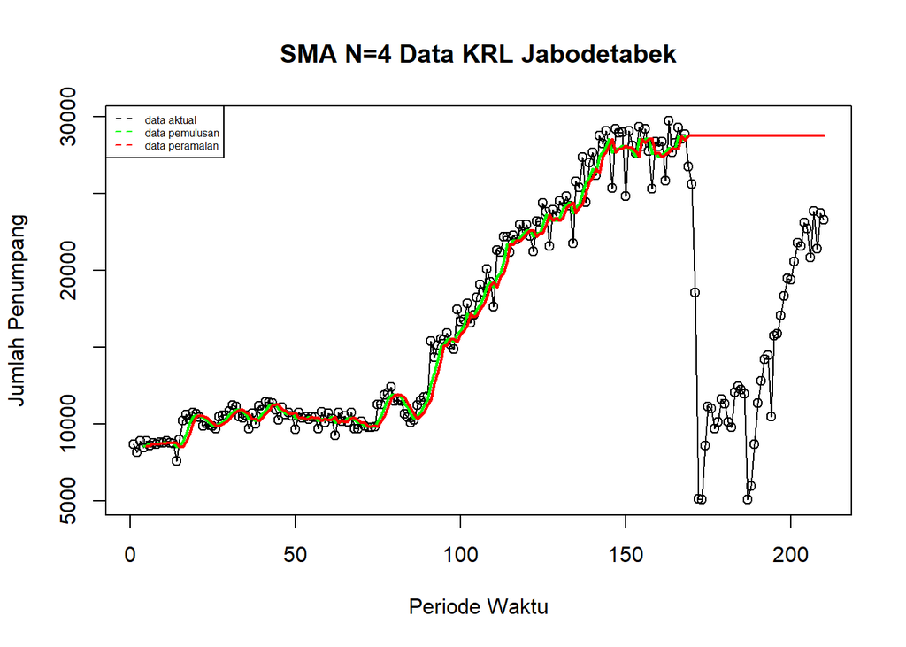

```r
ts.plot(data.ts, xlab="Periode Waktu", ylab="Jumlah Penumpang", main= "SMA N=4 Data KRL Jabodetabek")
points(data.ts)
lines(data.gab[,2],col="green",lwd=2)
lines(data.gab[,3],col="red",lwd=2)
legend("topleft",c("data aktual","data pemulusan","data peramalan"), lty=8, col=c("black","green","red"), cex=0.5)
```

```r
#Menyimpan Plot
dev.copy(png, "Plot Perbandingan Metode SMA.png")
```

```r
dev.off()
```

Selanjutnya perhitungan akurasi dilakukan dengan ukuran akurasi *Sum Squares Error* (SSE), *Mean Square Error* (MSE) dan *Mean Absolute Percentage Error* (MAPE). Perhitungan akurasi dilakukan baik pada data latih maupun pada data uji.

```r
#Menghitung nilai keakuratan data latih
error_train.sma = train_ma.ts-data.ramal[1:length(train_ma.ts)]
SSE_train.sma = sum(error_train.sma[5:length(train_ma.ts)]^2)
MSE_train.sma = mean(error_train.sma[5:length(train_ma.ts)]^2)
MAPE_train.sma = mean(abs((error_train.sma[5:length(train_ma.ts)]/train_ma.ts[5:length(train_ma.ts)])*100))

akurasi_train.sma <- matrix(c(SSE_train.sma, MSE_train.sma, MAPE_train.sma))
row.names(akurasi_train.sma)<- c("SSE", "MSE", "MAPE")
colnames(akurasi_train.sma) <- c("Akurasi m = 4")
akurasi_train.sma
```

```
##      Akurasi m = 4
## SSE   2.028739e+08
## MSE   1.237036e+06
## MAPE  5.004722e+00
```

```r
#Menghitung nilai keakuratan data uji
error_test.sma = test_ma.ts-data.gab[169:210,3]
SSE_test.sma = sum(error_test.sma^2)
MSE_test.sma = mean(error_test.sma^2)
MAPE_test.sma = mean(abs((error_test.sma/test_ma.ts*100)))

akurasi_test.sma <- matrix(c(SSE_test.sma, MSE_test.sma, MAPE_test.sma))
row.names(akurasi_test.sma)<- c("SSE", "MSE", "MAPE")
colnames(akurasi_test.sma) <- c("Akurasi m = 4")
akurasi_test.sma
```

```
##      Akurasi m = 4
## SSE   9.348570e+09
## MSE   2.225850e+08
## MAPE  1.325361e+02
```

Nilai MAPE data uji pada pemulusan SMA merupakan model yang buruk dengan nilai MAPE yang lebih dari 50%.

### Double Moving Average (DMA)

Metode pemulusan Double Moving Average (DMA) pada dasarnya mirip dengan SMA. Namun demikian, metode ini lebih cocok digunakan untuk pola data trend.

```r
dma <- SMA(data.sma, n = 4)
At <- 2*data.sma - dma
Bt <- 2/(4-1)*(data.sma - dma)
data.dma<- At+Bt
data.ramal2<- c(NA, data.dma)

t = 1:42
f = c()

for (i in t) {
  f[i] = At[length(At)] + Bt[length(Bt)]*(i)
}

data.gab2 <- cbind(aktual = c(train_ma.ts,rep(NA,42)), pemulusan1 = c(data.sma,rep(NA,42)),pemulusan2 = c(data.dma, rep(NA,42)),At = c(At, rep(NA,42)), Bt = c(Bt,rep(NA,42)),ramalan = c(data.ramal2, f[-1]))
data.gab2
```

```
##        aktual pemulusan1 pemulusan2        At           Bt   ramalan
##   [1,]   8681         NA         NA        NA           NA        NA
##   [2,]   8144         NA         NA        NA           NA        NA
##   [3,]   8920         NA         NA        NA           NA        NA
##   [4,]   8462    8551.75         NA        NA           NA        NA
##   [5,]   8899    8606.25         NA        NA           NA        NA
##   [6,]   8606    8721.75         NA        NA           NA        NA
##   [7,]   8787    8688.50   8765.896  8734.938   30.9583333        NA
##   [8,]   8661    8738.25   8820.854  8787.812   33.0416667  8765.896
##   [9,]   8829    8720.75   8726.479  8724.188    2.2916667  8820.854
##  [10,]   8767    8761.00   8817.458  8794.875   22.5833333  8726.479
##  [11,]   8895    8788.00   8848.000  8824.000   24.0000000  8817.458
##  [12,]   8774    8816.25   8890.833  8861.000   29.8333333  8848.000
##  [13,]   8723    8789.75   8791.417  8790.750    0.6666667  8890.833
##  [14,]   7566    8489.50   8103.875  8258.125 -154.2500000  8791.417
```

[output cut: 196 more lines]

Visualisasi hasil pemulusan menggunakan metode DMA

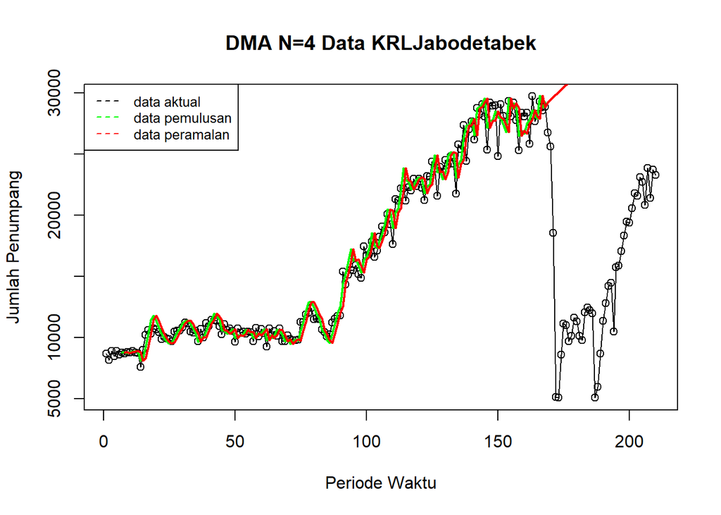

```r
ts.plot(data.ts, xlab="Periode Waktu", ylab="Jumlah Penumpang", main= "DMA N=4 Data KRLJabodetabek")
points(data.ts)
lines(data.gab2[,3],col="green",lwd=2)
lines(data.gab2[,6],col="red",lwd=2)
legend("topleft",c("data aktual","data pemulusan","data peramalan"), lty=8, col=c("black","green","red"), cex=0.8)
```

```r
#Menyimpan Plot
dev.copy(png, "Plot Perbandingan Metode DMA.png")
```

```r
dev.off()
```

Selanjutnya perhitungan akurasi dilakukan baik pada data latih maupun data uji. Perhitungan akurasi dilakukan dengan ukuran akurasi SSE, MSE dan MAPE.

```r
#Menghitung nilai keakuratan data latih
error_train.dma = train_ma.ts-data.ramal2[1:length(train_ma.ts)]
SSE_train.dma = sum(error_train.dma[8:length(train_ma.ts)]^2)
MSE_train.dma = mean(error_train.dma[8:length(train_ma.ts)]^2)
MAPE_train.dma = mean(abs((error_train.dma[8:length(train_ma.ts)]/train_ma.ts[8:length(train_ma.ts)])*100))

akurasi_train.dma <- matrix(c(SSE_train.dma, MSE_train.dma, MAPE_train.dma))
row.names(akurasi_train.dma)<- c("SSE", "MSE", "MAPE")
colnames(akurasi_train.dma) <- c("Akurasi m = 4")
akurasi_train.dma
```

```
##      Akurasi m = 4
## SSE   2.416288e+08
## MSE   1.500800e+06
## MAPE  5.265002e+00
```

```r
#Menghitung nilai keakuratan data uji
error_test.dma = test_ma.ts-data.gab2[169:210,6]
SSE_test.dma = sum(error_test.dma^2)
MSE_test.dma = mean(error_test.dma^2)
MAPE_test.dma = mean(abs((error_test.dma/test_ma.ts*100)))

akurasi_test.dma <- matrix(c(SSE_test.dma, MSE_test.dma, MAPE_test.dma))
row.names(akurasi_test.dma)<- c("SSE", "MSE", "MAPE")
colnames(akurasi_test.dma) <- c("Akurasi m = 4")
akurasi_test.dma
```

```
##      Akurasi m = 4
## SSE   1.505059e+10
## MSE   3.583473e+08
## MAPE  1.644805e+02
```

Nilai MAPE data uji pada pemulusan DMA merupakan model yang buruk dengan nilai MAPE yang lebih dari 50%.

## Single Exponential Smoothing & Double Exponential Smoothing

Metode *Exponential Smoothing* adalah metode pemulusan dengan melakukan pembobotan menurun secara eksponensial. Nilai yang lebih baru diberi bobot yang lebih besar dari nilai terdahulu. Terdapat satu atau lebih parameter pemulusan yang ditentukan secara eksplisit, dan hasil pemilihan parameter tersebut akan menentukan bobot yang akan diberikan pada nilai pengamatan. Ada dua macam model, yaitu model tunggal dan ganda.

### Pembagian Data

Pembagian data latih dan data uji dilakukan dengan perbandingan 80% data latih dan 20% data uji.

```r
#membagi training dan testing
Periode1 <- c(1:168)
Periode2 <- c(169:210)
training<- cbind(data[1:168,],Periode1)
testing <- cbind(data[169:210,],Periode2)
train.ts <- ts(training$`Jumlah penumpang KRL Jabodetabek (Ribu jiwa)`)
test.ts <- ts(testing$`Jumlah penumpang KRL Jabodetabek (Ribu jiwa)`)
```

### Eksplorasi

Eksplorasi dilakukan dengan membuat plot data deret waktu untuk keseluruhan data, data latih, dan data uji.

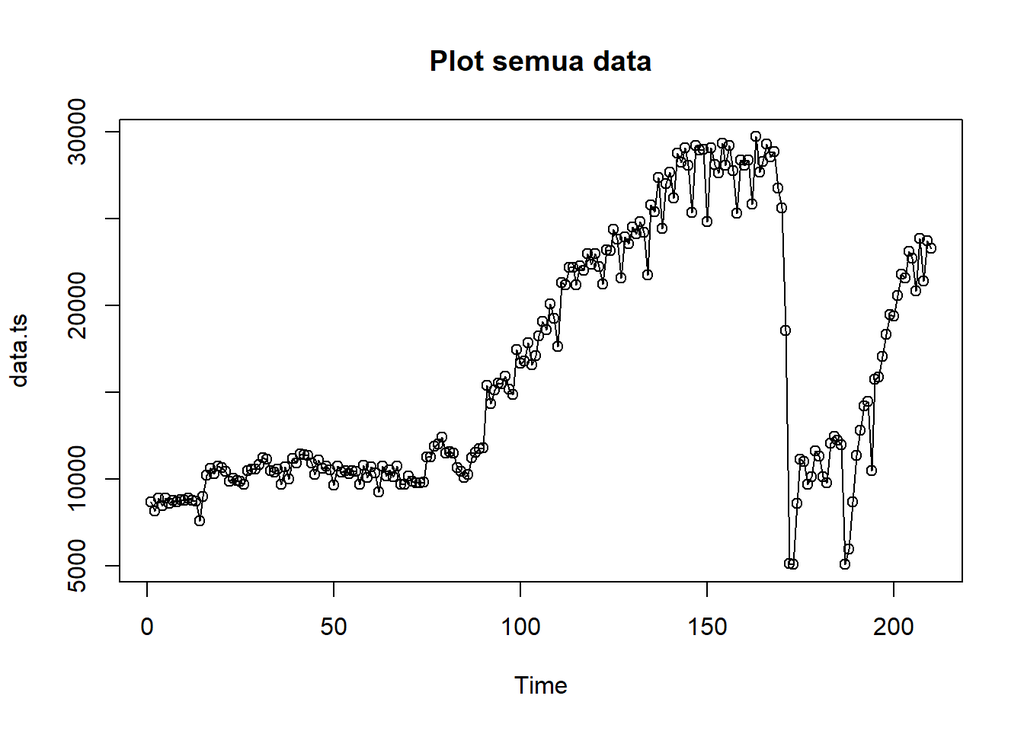

```r
plot(data.ts, col="black",main="Plot semua data")
points(data.ts)
```

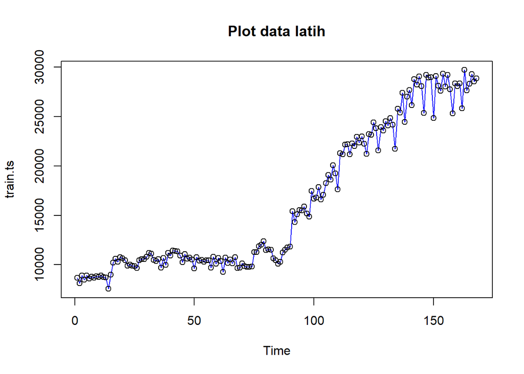

```r
plot(train.ts, col="blue",main="Plot data latih")
points(train.ts)
```

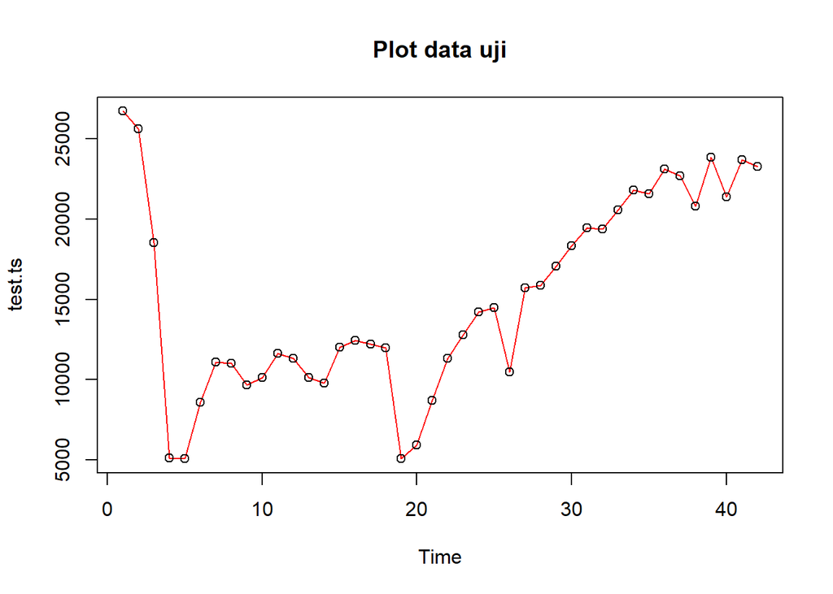

```r
plot(test.ts, col="red",main="Plot data uji")
points(test.ts)
```

Eksplorasi data juga dapat dilakukan menggunakan package `ggplot2` .

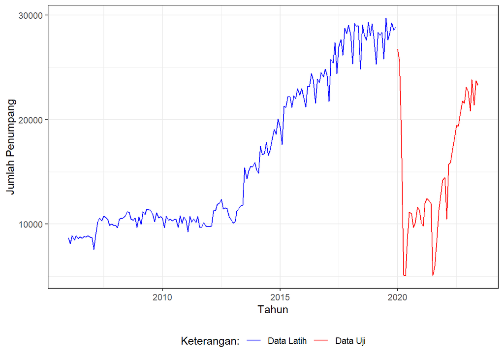

```r
library(ggplot2)
ggplot() +
  geom_line(data = training_ma, aes(x = Date, y = `Jumlah penumpang KRL Jabodetabek (Ribu jiwa)`, col = "Data Latih")) +
  geom_line(data = testing_ma, aes(x = Date, y = `Jumlah penumpang KRL Jabodetabek (Ribu jiwa)`, col = "Data Uji")) +
  labs(x = "Tahun", y = "Jumlah Penumpang", color = "Legend") +
  scale_colour_manual(name="Keterangan:", breaks = c("Data Latih", "Data Uji"),
                      values = c("blue", "red")) +
  theme_bw() + theme(legend.position = "bottom",
                     plot.caption = element_text(hjust=0.5, size=12))
```

### Single Exponential Smoothing (SES)

Single Exponential Smoothing merupakan metode pemulusan yang tepat digunakan untuk data dengan pola stasioner atau konstan.

Nilai pemulusan pada periode ke-t didapat dari persamaan:

$$\tilde{y}_T=\lambda y_t+(1-\lambda)\tilde{y}_{T-1}$$

Nilai parameter $\lambda$ adalah nilai antara 0 dan 1.

Nilai pemulusan periode ke-t bertindak sebagai nilai ramalan pada periode ke-$(T+\tau)$.

$$\tilde{y}_{T+\tau}(T)=\tilde{y}_T$$

Pemulusan dengan metode SES dapat dilakukan dengan dua fungsidari *packages* berbeda, yaitu (1) fungsi `ses()` dari *packages* `forecast` dan (2) fungsi `HoltWinters` dari *packages* `stats`.

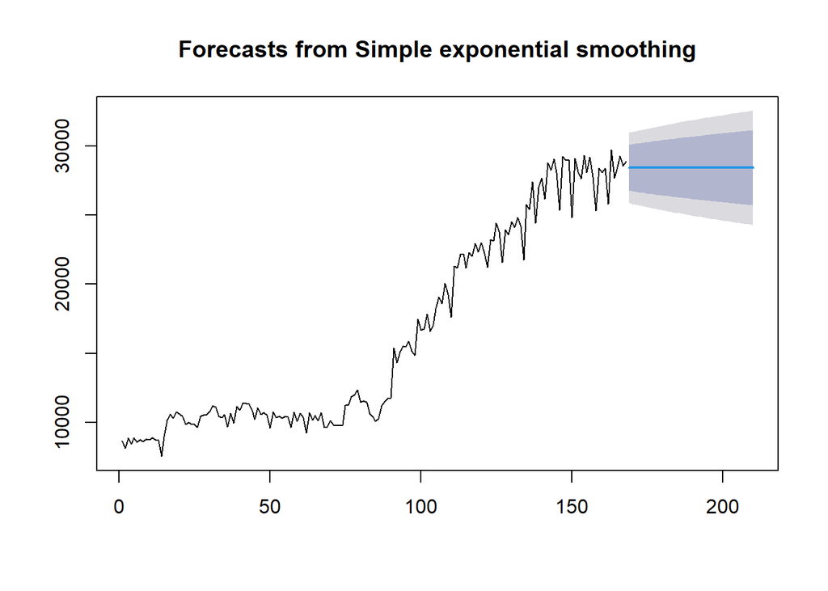

```r
#Cara 1 (fungsi ses)
ses.1 <- ses(train.ts, h = 42, alpha = 0.2)
plot(ses.1)
```

```r
ses.1
```

```
##     Point Forecast    Lo 80    Hi 80    Lo 95    Hi 95
## 169        28410.2 26748.27 30072.13 25868.50 30951.90
## 170        28410.2 26715.36 30105.05 25818.16 31002.24
## 171        28410.2 26683.07 30137.33 25768.79 31051.62
## 172        28410.2 26651.38 30169.02 25720.32 31100.09
## 173        28410.2 26620.25 30200.16 25672.71 31147.70
## 174        28410.2 26589.65 30230.76 25625.91 31194.50
## 175        28410.2 26559.56 30260.85 25579.88 31240.52
## 176        28410.2 26529.94 30290.46 25534.59 31285.81
## 177        28410.2 26500.79 30319.61 25490.01 31330.40
## 178        28410.2 26472.08 30348.33 25446.09 31374.31
## 179        28410.2 26443.78 30376.62 25402.82 31417.59
## 180        28410.2 26415.89 30404.52 25360.16 31460.25
## 181        28410.2 26388.38 30432.03 25318.09 31502.32
## 182        28410.2 26361.24 30459.17 25276.58 31543.82
```

[output cut: 28 more lines]

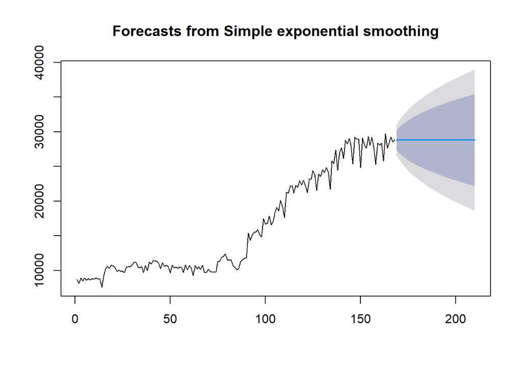

```r
ses.2 <- ses(train.ts, h = 42, alpha = 0.7)
plot(ses.2)
```

```r
ses.2
```

```
##     Point Forecast    Lo 80    Hi 80    Lo 95    Hi 95
## 169       28806.16 27359.70 30252.61 26594.00 31018.32
## 170       28806.16 27040.53 30571.78 26105.87 31506.44
## 171       28806.16 26770.82 30841.50 25693.37 31918.94
## 172       28806.16 26532.88 31079.44 25329.47 32282.84
## 173       28806.16 26317.58 31294.73 25000.21 32612.10
## 174       28806.16 26119.49 31492.83 24697.25 32915.06
## 175       28806.16 25935.03 31677.29 24415.14 33197.17
## 176       28806.16 25761.72 31850.59 24150.10 33462.22
## 177       28806.16 25597.77 32014.55 23899.35 33712.97
## 178       28806.16 25441.79 32170.52 23660.80 33951.51
## 179       28806.16 25292.73 32319.58 23432.84 34179.48
## 180       28806.16 25149.74 32462.57 23214.16 34398.16
## 181       28806.16 25012.14 32600.17 23003.71 34608.60
## 182       28806.16 24879.36 32732.95 22800.64 34811.68
```

[output cut: 28 more lines]

Untuk mendapatkan gambar hasil pemulusan pada data latih dengan fungsi `ses()` , perlu digunakan fungsi `autoplot()` dan `autolayer()`.

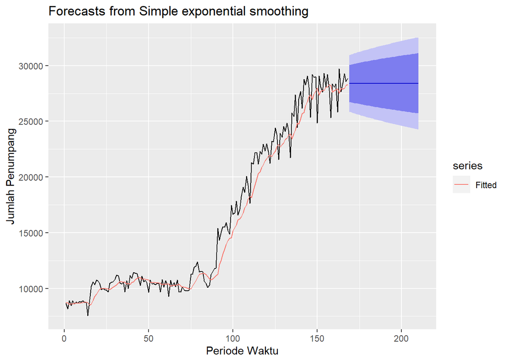

```r
autoplot(ses.1) +
  autolayer(fitted(ses.1), series="Fitted") +
  ylab("Jumlah Penumpang") + xlab("Periode Waktu")
```

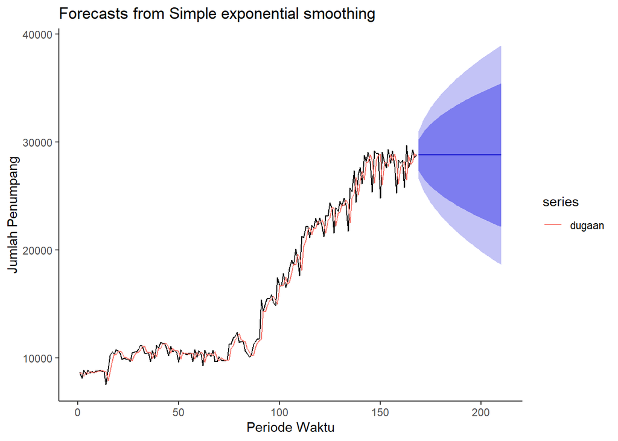

```r
autoplot(ses.2) +
  autolayer(fitted(ses.2), series="dugaan") +
  ylab("Jumlah Penumpang") + xlab("Periode Waktu") + theme_classic()
```

Pada fungsi `ses()` , terdapat beberapa argumen yang umum digunakan, yaitu nilia `y` , `gamma` , `beta` , `alpha` , dan `h`.

Nilai `y` adalah nilai data deret waktu, `gamma` adalah parameter pemulusan untuk komponen musiman, `beta` adalah parameter pemulusan untuk tren, dan `alpha` adalah parameter pemulusan untuk stasioner, serta `h` adalah banyaknya periode yang akan diramalkan.

Kasus di atas merupakan contoh inisialisasi nilai parameter $\lambda$ dengan nilai `alpha` 0,2 dan 0,7 dan banyak periode data yang akan diramalkan adalah sebanyak 42 periode.

```r
#ramalan
ramalan1<- predict(ses.1, h=42)
ramalan1
```

```
##     Point Forecast    Lo 80    Hi 80    Lo 95    Hi 95
## 169        28410.2 26748.27 30072.13 25868.50 30951.90
## 170        28410.2 26715.36 30105.05 25818.16 31002.24
## 171        28410.2 26683.07 30137.33 25768.79 31051.62
## 172        28410.2 26651.38 30169.02 25720.32 31100.09
## 173        28410.2 26620.25 30200.16 25672.71 31147.70
## 174        28410.2 26589.65 30230.76 25625.91 31194.50
## 175        28410.2 26559.56 30260.85 25579.88 31240.52
## 176        28410.2 26529.94 30290.46 25534.59 31285.81
## 177        28410.2 26500.79 30319.61 25490.01 31330.40
## 178        28410.2 26472.08 30348.33 25446.09 31374.31
## 179        28410.2 26443.78 30376.62 25402.82 31417.59
## 180        28410.2 26415.89 30404.52 25360.16 31460.25
## 181        28410.2 26388.38 30432.03 25318.09 31502.32
## 182        28410.2 26361.24 30459.17 25276.58 31543.82
```

[output cut: 28 more lines]

```r
ramalan2<- predict(ses.2, h=42)
ramalan2
```

```
##     Point Forecast    Lo 80    Hi 80    Lo 95    Hi 95
## 169       28806.16 27359.70 30252.61 26594.00 31018.32
## 170       28806.16 27040.53 30571.78 26105.87 31506.44
## 171       28806.16 26770.82 30841.50 25693.37 31918.94
## 172       28806.16 26532.88 31079.44 25329.47 32282.84
## 173       28806.16 26317.58 31294.73 25000.21 32612.10
## 174       28806.16 26119.49 31492.83 24697.25 32915.06
## 175       28806.16 25935.03 31677.29 24415.14 33197.17
## 176       28806.16 25761.72 31850.59 24150.10 33462.22
## 177       28806.16 25597.77 32014.55 23899.35 33712.97
## 178       28806.16 25441.79 32170.52 23660.80 33951.51
## 179       28806.16 25292.73 32319.58 23432.84 34179.48
## 180       28806.16 25149.74 32462.57 23214.16 34398.16
## 181       28806.16 25012.14 32600.17 23003.71 34608.60
## 182       28806.16 24879.36 32732.95 22800.64 34811.68
```

[output cut: 28 more lines]

Fungsi `HoltWinters` memiliki argumen yang sama dengan fungsi `ses()` . Argumen-argumen kedua fungsi dapat dilihat lebih lanjut dengan `?ses()` atau `?HoltWinters`.

Nilai parameter $\alpha$ dari kedua fungsi dapat dioptimalkan menyesuaikan dari *error*-nya paling minimumnya. Caranya adalah dengan membuat parameter $\alpha =$ `NULL` .

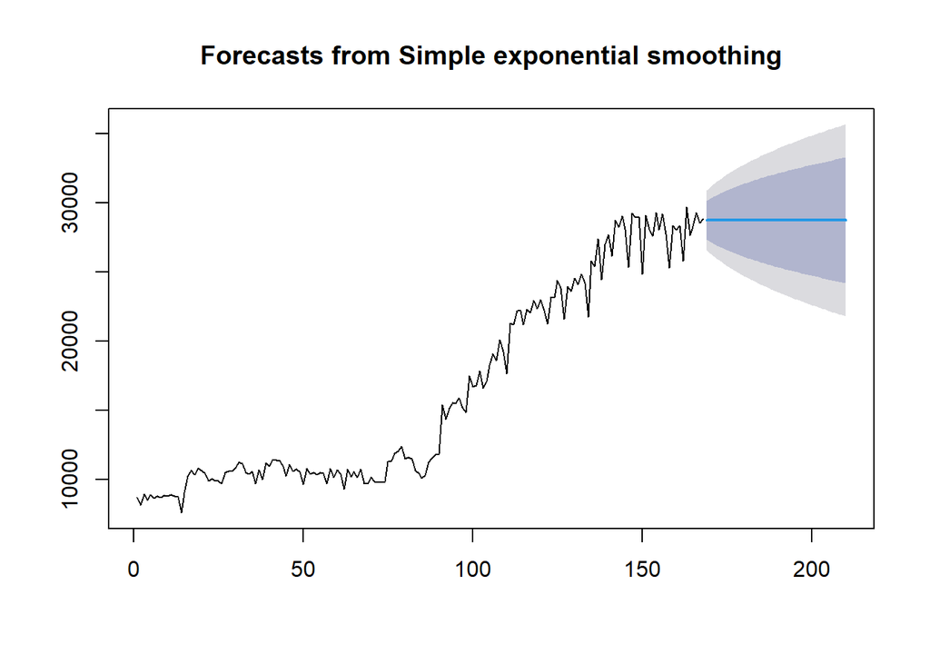

```r
#SES
ses.opt <- ses(train.ts, h = 42, alpha = NULL)
plot(ses.opt)
```

```r
ses.opt
```

```
##     Point Forecast    Lo 80    Hi 80    Lo 95    Hi 95
## 169       28739.48 27341.99 30136.97 26602.21 30876.75
## 170       28739.48 27187.77 30291.20 26366.34 31112.62
## 171       28739.48 27047.54 30431.42 26151.88 31327.08
## 172       28739.48 26918.08 30560.88 25953.89 31525.08
## 173       28739.48 26797.23 30681.74 25769.06 31709.90
## 174       28739.48 26683.47 30795.50 25595.08 31883.88
## 175       28739.48 26575.68 30903.28 25430.23 32048.73
## 176       28739.48 26473.01 31005.95 25273.22 32205.75
## 177       28739.48 26374.80 31104.16 25123.01 32355.95
## 178       28739.48 26280.50 31198.46 24978.80 32500.16
## 179       28739.48 26189.70 31289.27 24839.92 32639.04
## 180       28739.48 26102.01 31376.95 24705.82 32773.15
## 181       28739.48 26017.15 31461.82 24576.03 32902.93
## 182       28739.48 25934.85 31544.11 24450.17 33028.79
```

[output cut: 28 more lines]

```r
#ramalan
ramalanopt<- predict(ses.opt, h=42)
ramalanopt
```

```
##     Point Forecast    Lo 80    Hi 80    Lo 95    Hi 95
## 169       28739.48 27341.99 30136.97 26602.21 30876.75
## 170       28739.48 27187.77 30291.20 26366.34 31112.62
## 171       28739.48 27047.54 30431.42 26151.88 31327.08
## 172       28739.48 26918.08 30560.88 25953.89 31525.08
## 173       28739.48 26797.23 30681.74 25769.06 31709.90
## 174       28739.48 26683.47 30795.50 25595.08 31883.88
## 175       28739.48 26575.68 30903.28 25430.23 32048.73
## 176       28739.48 26473.01 31005.95 25273.22 32205.75
## 177       28739.48 26374.80 31104.16 25123.01 32355.95
## 178       28739.48 26280.50 31198.46 24978.80 32500.16
## 179       28739.48 26189.70 31289.27 24839.92 32639.04
## 180       28739.48 26102.01 31376.95 24705.82 32773.15
## 181       28739.48 26017.15 31461.82 24576.03 32902.93
## 182       28739.48 25934.85 31544.11 24450.17 33028.79
```

[output cut: 28 more lines]

#### Akurasi Data Latih

Nilai akurasi dapat diambil dari objek yang tersimpan pada hasil SES, yaitu *sum of squared errors* (SSE). Nilai akurasi lain dapat dihitung pula dari nilai SSE tersebut.

```r
#Keakuratan Metode
#Pada data training
SSE1<-sum(ses.1$residuals^2)
MSE1<-sum(ses.1$residuals^2)/length(train.ts)
RMSE1<-sqrt(MSE1)

akurasi1 <- matrix(c(SSE1,MSE1,RMSE1))
row.names(akurasi1)<- c("SSE", "MSE", "RMSE")
colnames(akurasi1) <- c("Akurasi lamda=0.2")
akurasi1
```

```
##      Akurasi lamda=0.2
## SSE       2.791652e+08
## MSE       1.661698e+06
## RMSE      1.289069e+03
```

```r
SSE2<-sum(ses.2$residuals^2)
MSE2<-sum(ses.2$residuals^2)/length(train.ts)
RMSE2<-sqrt(MSE2)

akurasi2 <- matrix(c(SSE2,MSE2,RMSE2))
row.names(akurasi2)<- c("SSE", "MSE", "RMSE")
colnames(akurasi2) <- c("Akurasi lamda=0.7")
akurasi2
```

```
##      Akurasi lamda=0.7
## SSE       2.114684e+08
## MSE       1.258740e+06
## RMSE      1.121936e+03
```

```r
#Cara Manual
fitted1<-ramalan1$fitted
sisaan1<-ramalan1$residuals
head(sisaan1)
```

```
## Time Series:
## Start = 1
## End = 6
## Frequency = 1
## [1]   -4.766719 -540.813375  343.349300 -183.320560  290.343552  -60.725158
```

```r
resid1<-training$`Jumlah penumpang KRL Jabodetabek (Ribu jiwa)`-ramalan2$fitted
head(resid1)
```

```
## Time Series:
## Start = 1
## End = 6
## Frequency = 1
## [1]  100.2894 -506.9132  623.9260 -270.8222  355.7533 -186.2740
```

```r
#Cara Manual
SSE.1=sum(sisaan1[2:length(train.ts)]^2)
SSE.1
```

```
## [1] 279165196
```

```r
MSE.1 = SSE.1/length(train.ts)
MSE.1
```

```
## [1] 1661698
```

```r
MAPE.1 = sum(abs(sisaan1[2:length(train.ts)]/train.ts[2:length(train.ts)])*
               100)/length(train.ts)
MAPE.1
```

```
## [1] 5.718804
```

```r
akurasi.1 <- matrix(c(SSE.1,MSE.1,MAPE.1))
row.names(akurasi.1)<- c("SSE", "MSE", "MAPE")
colnames(akurasi.1) <- c("Akurasi lamda=0.2")
akurasi.1
```

```
##      Akurasi lamda=0.2
## SSE       2.791652e+08
## MSE       1.661698e+06
## MAPE      5.718804e+00
```

```r
fitted2<-ramalan2$fitted
sisaan2<-ramalan2$residuals
head(sisaan2)
```

```
## Time Series:
## Start = 1
## End = 6
## Frequency = 1
## [1]  100.2894 -506.9132  623.9260 -270.8222  355.7533 -186.2740
```

```r
resid2<-training$`Jumlah penumpang KRL Jabodetabek (Ribu jiwa)`-ramalan2$fitted
head(resid2)
```

```
## Time Series:
## Start = 1
## End = 6
## Frequency = 1
## [1]  100.2894 -506.9132  623.9260 -270.8222  355.7533 -186.2740
```

```r
SSE.2=sum(sisaan2[2:length(train.ts)]^2)
SSE.2
```

```
## [1] 211458311
```

```r
MSE.2 = SSE.2/length(train.ts)
MSE.2
```

```
## [1] 1258680
```

```r
MAPE.2 = sum(abs(sisaan2[2:length(train.ts)]/train.ts[2:length(train.ts)])*
               100)/length(train.ts)
MAPE.2
```

```
## [1] 4.510729
```

```r
akurasi.2 <- matrix(c(SSE.2,MSE.2,MAPE.2))
row.names(akurasi.2)<- c("SSE", "MSE", "MAPE")
colnames(akurasi.2) <- c("Akurasi lamda=0.7")
akurasi.2
```

```
##      Akurasi lamda=0.7
## SSE       2.114583e+08
## MSE       1.258680e+06
## MAPE      4.510729e+00
```

Berdasarkan nilai SSE, MSE, RMSE, dan MAPE di antara kedua parameter, nilai parameter $\lambda=0,7$ menghasilkan akurasi yang lebih baik dibanding $\lambda=0,2$ . Hal ini dilihat dari nilai masing-masing ukuran akurasi yang lebih kecil. Berdasarkan nilai MAPE-nya, hasil ini dapat dikategorikan sebagai peramalan sangat baik.

#### Akurasi Data Uji

Akurasi data uji dapat dihitung dengan cara yang hampir sama dengan perhitungan akurasi data latih.

```r
selisih1<-ramalan1$mean-testing$`Jumlah penumpang KRL Jabodetabek (Ribu jiwa)`
SSEtesting1<-sum(selisih1^2)
MSEtesting1<-SSEtesting1/length(testing)

selisih2<-ramalan2$mean-testing$`Jumlah penumpang KRL Jabodetabek (Ribu jiwa)`
SSEtesting2<-sum(selisih2^2)
MSEtesting2<-SSEtesting2/length(testing)
MAPEtesting2 <- sum(abs(sisaan2[2:length(test.ts)]/test.ts[2:length(test.ts)])*100)/length(test.ts)

selisihopt<-ramalanopt$mean-testing$`Jumlah penumpang KRL Jabodetabek (Ribu jiwa)`
SSEtestingopt<-sum(selisihopt^2)
MSEtestingopt<-SSEtestingopt/length(testing)

akurasitesting1 <- matrix(c(SSEtesting1,SSEtesting2,SSEtestingopt))
row.names(akurasitesting1)<- c("SSE1", "SSE2", "SSEopt")
akurasitesting1
```

```
##              [,1]
## SSE1   8966129753
## SSE2   9414709839
## SSEopt 9338250772
```

```r
akurasitesting2 <- matrix(c(MSEtesting1,MSEtesting2,MSEtestingopt))
row.names(akurasitesting2)<- c("MSE1", "MSE2", "MSEopt")
akurasitesting2
```

```
##              [,1]
## MSE1   2988709918
## MSE2   3138236613
## MSEopt 3112750257
```

Selain dengan cara di atas, perhitungan nilai akurasi dapat menggunakan fungsi `accuracy()` dari *package* `forecast` . Penggunaannya yaitu dengan menuliskan `accuracy(hasil ramalan, kondisi aktual)`

```r
#cara lain
akurasi_ses <- accuracy(ramalanopt, testing$`Jumlah penumpang KRL Jabodetabek (Ribu jiwa)`)
akurasi_ses
```

```
##                     ME      RMSE        MAE        MPE       MAPE       MASE
## Training set    248.75  1083.955   776.7784    1.20441   4.663478  0.9061013
## Test set     -13618.29 14911.046 13618.2915 -132.46314 132.463137 15.8855494
##                    ACF1
## Training set -0.1391029
## Test set             NA
```

### DES

Metode pemulusan *Double Exponential Smoothing* (DES) digunakan untuk data yang memiliki pola tren. Metode DES adalah metode semacam SES, hanya saja dilakukan dua kali, yaitu pertama untuk tahapan ‘level’ dan kedua untuk tahapan ‘tren’. Pemulusan menggunakan metode ini akan menghasilkan peramalan tidak konstan untuk periode berikutnya.

Pemulusan dengan metode DES kali ini akan menggunakan fungsi `HoltWinters()` . Jika sebelumnya nilai argumen `beta` dibuat `FALSE` , kali ini argumen tersebut akan diinisialisasi bersamaan dengan nilai `alpha`.

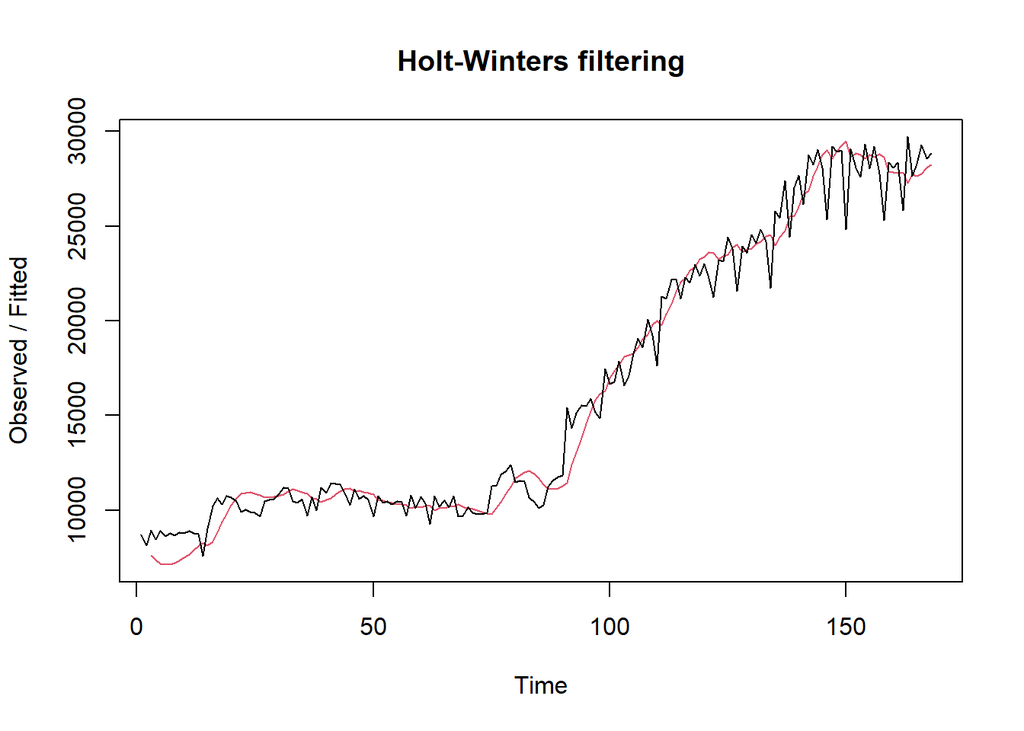

```r
#Lamda=0.2 dan gamma=0.2
des.1<- HoltWinters(train.ts, gamma = FALSE, beta = 0.2, alpha = 0.2)
plot(des.1)
```

```r
#ramalan
ramalandes1<- predict(des.1, n=42)
ramalandes1
```

```
## Time Series:
## Start = 169
## End = 210
## Frequency = 1
##            fit
##  [1,] 28434.16
##  [2,] 28509.79
##  [3,] 28585.41
##  [4,] 28661.04
##  [5,] 28736.67
##  [6,] 28812.29
##  [7,] 28887.92
##  [8,] 28963.54
##  [9,] 29039.17
## [10,] 29114.80
```

[output cut: 32 more lines]

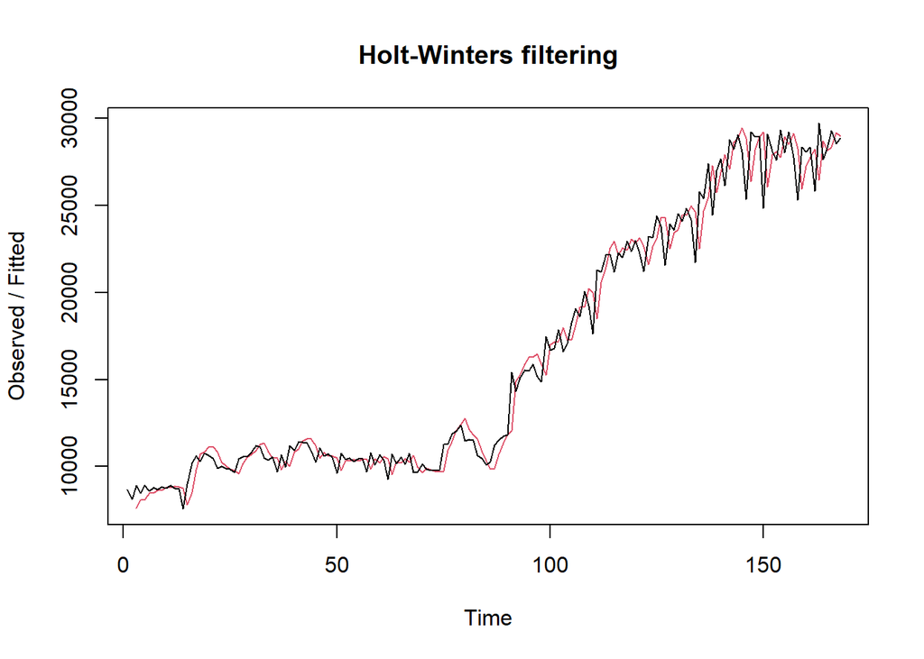

```r
#Lamda=0.6 dan gamma=0.3
des.2<- HoltWinters(train.ts, gamma = FALSE, beta = 0.3, alpha = 0.6)
plot(des.2)
```

```r
#ramalan
ramalandes2<- predict(des.2, n=42)
ramalandes2
```

```
## Time Series:
## Start = 169
## End = 210
## Frequency = 1
##            fit
##  [1,] 29051.18
##  [2,] 29195.94
##  [3,] 29340.69
##  [4,] 29485.44
##  [5,] 29630.19
##  [6,] 29774.94
##  [7,] 29919.69
##  [8,] 30064.45
##  [9,] 30209.20
## [10,] 30353.95
```

[output cut: 32 more lines]

Membandingkan plot data latih dan data uji

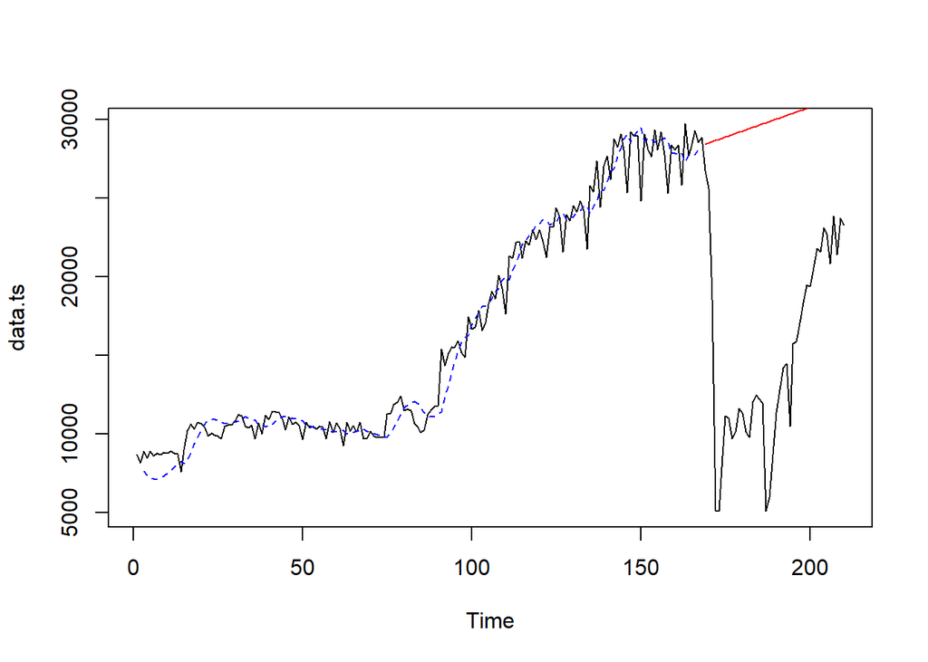

```r
#Visually evaluate the prediction
plot(data.ts)
lines(des.1$fitted[,1], lty=2, col="blue")
lines(ramalandes1, col="red")
```

Untuk mendapatkan nilai parameter optimum dari DES, argumen `alpha` dan `beta` dapat dibuat `NULL`.

```r
#Lamda dan gamma optimum
des.opt<- HoltWinters(train.ts, gamma = FALSE)
des.opt
```

```
## Holt-Winters exponential smoothing with trend and without seasonal component.
##
## Call:
## HoltWinters(x = train.ts, gamma = FALSE)
##
## Smoothing parameters:
##  alpha: 0.4135085
##  beta : 0.1149797
##  gamma: FALSE
##
## Coefficients:
##          [,1]
## a 28785.37100
## b    88.98232
```

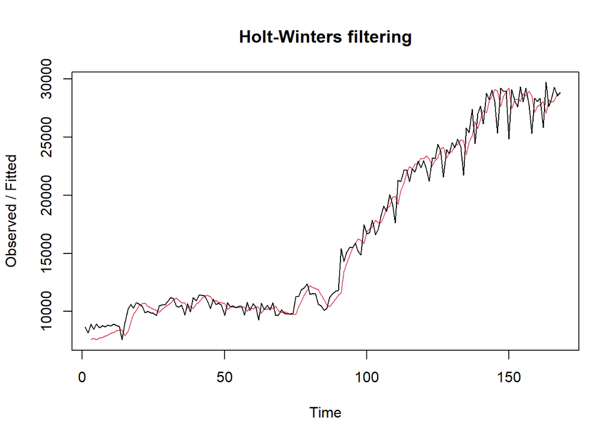

```r
plot(des.opt)
```

```r
#ramalan
ramalandesopt<- predict(des.opt, n=42)
ramalandesopt
```

```
## Time Series:
## Start = 169
## End = 210
## Frequency = 1
##            fit
##  [1,] 28874.35
##  [2,] 28963.34
##  [3,] 29052.32
##  [4,] 29141.30
##  [5,] 29230.28
##  [6,] 29319.26
##  [7,] 29408.25
##  [8,] 29497.23
##  [9,] 29586.21
## [10,] 29675.19
```

[output cut: 32 more lines]

#### Akurasi Data Uji

```r
#Akurasi Data Testing
selisihdes1<-ramalandes1-testing$`Jumlah penumpang KRL Jabodetabek (Ribu jiwa)`
selisihdes1
```

```
## Time Series:
## Start = 169
## End = 210
## Frequency = 1
##             fit
##  [1,]  1701.160
##  [2,]  2893.786
##  [3,] 10037.413
##  [4,] 23523.039
##  [5,] 23659.666
##  [6,] 20221.292
##  [7,] 17771.918
##  [8,] 17949.545
##  [9,] 19361.171
## [10,] 18986.798
```

[output cut: 32 more lines]

```r
SSEtestingdes1<-sum(selisihdes1^2)
MSEtestingdes1<-SSEtestingdes1/length(testing$`Jumlah penumpang KRL Jabodetabek (Ribu jiwa)`)
MAPEtestingdes1<-sum(abs(selisihdes1/testing$`Jumlah penumpang KRL Jabodetabek (Ribu jiwa)`)*100)/length(testing$`Jumlah penumpang KRL Jabodetabek (Ribu jiwa)`)

selisihdes2<-ramalandes2-testing$`Jumlah penumpang KRL Jabodetabek (Ribu jiwa)`
selisihdes2
```

```
## Time Series:
## Start = 169
## End = 210
## Frequency = 1
##             fit
##  [1,]  2318.184
##  [2,]  3579.936
##  [3,] 10792.688
##  [4,] 24347.439
##  [5,] 24553.191
##  [6,] 21183.942
##  [7,] 18803.694
##  [8,] 19050.446
##  [9,] 20531.197
## [10,] 20225.949
```

[output cut: 32 more lines]

```r
SSEtestingdes2<-sum(selisihdes2^2)
MSEtestingdes2<-SSEtestingdes2/length(testing$`Jumlah penumpang KRL Jabodetabek (Ribu jiwa)`)
MAPEtestingdes2<-sum(abs(selisihdes2/testing$`Jumlah penumpang KRL Jabodetabek (Ribu jiwa)`)*100)/length(testing$`Jumlah penumpang KRL Jabodetabek (Ribu jiwa)`)

selisihdesopt<-ramalandesopt-testing$`Jumlah penumpang KRL Jabodetabek (Ribu jiwa)`
selisihdesopt
```

```
## Time Series:
## Start = 169
## End = 210
## Frequency = 1
##             fit
##  [1,]  2141.353
##  [2,]  3347.336
##  [3,] 10504.318
##  [4,] 24003.300
##  [5,] 24153.283
##  [6,] 20728.265
##  [7,] 18292.247
##  [8,] 18483.230
##  [9,] 19908.212
## [10,] 19547.194
```

[output cut: 32 more lines]

```r
SSEtestingdesopt<-sum(selisihdesopt^2)
MSEtestingdesopt<-SSEtestingdesopt/length(testing$`Jumlah penumpang KRL Jabodetabek (Ribu jiwa)`)
MAPEtestingdesopt<-sum(abs(selisihdesopt/testing$`Jumlah penumpang KRL Jabodetabek (Ribu jiwa)`)*100)/length(testing$`Jumlah penumpang KRL Jabodetabek (Ribu jiwa)`)

akurasitestingdes <-
  matrix(c(SSEtestingdes1,MSEtestingdes1,MAPEtestingdes1,SSEtestingdes2,MSEtestingdes2,
           MAPEtestingdes2,SSEtestingdesopt,MSEtestingdesopt,MAPEtestingdesopt),
         nrow=3,ncol=3)
row.names(akurasitestingdes)<- c("SSE", "MSE", "MAPE")
colnames(akurasitestingdes) <- c("des ske1","des ske2","des opt")
akurasitestingdes
```

```
##          des ske1     des ske2      des opt
## SSE  1.060553e+10 1.317769e+10 1.148649e+10
## MSE  2.525126e+08 3.137544e+08 2.734878e+08
## MAPE 1.405762e+02 1.552401e+02 1.460057e+02
```

## Pemulusan Data Musiman

```r
#Import data
library(rio)
data1 <- import("https://raw.githubusercontent.com/yoginurhamid/MPDW/main/Data/Data%20Prak%201.xlsx")
data1
```

```
##           Date Jumlah penumpang KRL Jabodetabek (Ribu jiwa)
## 1   2006-01-01                                         8681
## 2   2006-02-01                                         8144
## 3   2006-03-01                                         8920
## 4   2006-04-01                                         8462
## 5   2006-05-01                                         8899
## 6   2006-06-01                                         8606
## 7   2006-07-01                                         8787
## 8   2006-08-01                                         8661
## 9   2006-09-01                                         8829
## 10  2006-10-01                                         8767
## 11  2006-11-01                                         8895
## 12  2006-12-01                                         8774
## 13  2007-01-01                                         8723
## 14  2007-02-01                                         7566
```

[output cut: 196 more lines]

```r
data1.ts <- ts(data1$`Jumlah penumpang KRL Jabodetabek (Ribu jiwa)`)
```

Mengubah format Tanggal dan Jumlah

```r
data1$Date <- as.Date(data1$Date, format="%Y-%m-%d")
data1$`Jumlah penumpang KRL Jabodetabek (Ribu jiwa)` <- as.numeric(data1$`Jumlah penumpang KRL Jabodetabek (Ribu jiwa)`)
str(data1$Date);str(data1$`Jumlah penumpang KRL Jabodetabek (Ribu jiwa)`)
```

```
##  Date[1:210], format: "2006-01-01" "2006-02-01" "2006-03-01" "2006-04-01" "2006-05-01" ...
```

```
##  num [1:210] 8681 8144 8920 8462 8899 ...
```

```r
#membagi data menjadi training dan testing
training<-data1[1:168,2]
testing<-data1[169:210,2]
#data bulanan -> pola tahunan -> freq = 12
training.ts<-ts(training, frequency = 12)
testing.ts<-ts(testing, frequency = 12)
```

Metode Holt-Winter untuk peramalan data musiman menggunakan tiga persamaan pemulusan yang terdiri atas persamaan untuk level $(L_t)$, trend $(B_t)$, dan komponen seasonal / musiman $(S_t)$ dengan parameter pemulusan berupa $\alpha$, $\beta$, dan $\gamma$. Metode Holt-Winter musiman terbagi menjadi dua, yaitu metode aditif dan metode multiplikatif.

Pemulusan data musiman dengan metode Winter dilakukan menggunakan fungsi `HoltWinters()` dengan memasukkan argumen tambahan, yaitu `gamma()` dan `seasonal()` . Arguman `seasonal()` diinisialisasi menyesuaikan jenis musiman, aditif atau multiplikatif.

### Winter Aditif

Perhitungan dengan model aditif dilakukan jika plot data asli menunjukkan fluktuasi musiman yang relatif stabil (konstan).

#### Pemulusan

```r
#Pemulusan dengan winter aditif
winter1 <- HoltWinters(training.ts,alpha=0.2,beta=0.1,gamma=0.1,seasonal = "additive")
winter1$fitted
```

```
##             xhat     level      trend        season
## Jan  2  8115.416  8397.958 115.722319  -398.2638889
## Feb  2  7042.557  8635.197 127.873997 -1720.5138889
## Mar  2  8578.213  8867.759 138.342859  -427.8888889
## Apr  2  9894.288  9092.260 146.958591   655.0694444
## May  2 10417.823  9301.561 153.192838   963.0694444
## Jun  2 10220.813  9492.789 156.996380   571.0277778
## Jul  2  9965.139  9667.623 158.780118   138.7361111
## Aug  2 10195.342  9985.575 174.697340    35.0694444
## Sep  2 10659.099 10251.804 183.850504   223.4444444
## Oct  2 10657.693 10393.035 179.588525    85.0694444
## Nov  2 10651.854 10418.485 164.174672    69.1944444
## Dec  2 10416.232 10458.489 151.757596  -194.0138889
## Jan  3 10297.676 10506.000 141.332949  -349.6571795
## Feb  3  9015.499 10561.398 132.739439 -1678.6384411
## Mar  3 10578.101 10825.637 145.889467  -393.4259594
## Apr  3 11773.420 10949.707 143.707451   680.0064341
## May  3 11948.893 10851.130 119.479041   978.2836091
## Jun  3 11367.534 10697.230  92.141189   578.1627325
## Jul  3 10964.340 10680.665  81.270501   202.4049987
## Aug  3 10968.053 10810.267  86.103695    71.6821007
## Sep  3 11224.279 10928.560  89.322634   206.3965291
## Oct  3 10967.098 10869.227  74.457045    23.4140301
## Nov  3 10908.286 10826.064  62.695082    19.5261392
## Dec  3 10644.179 10823.702  56.189368  -235.7124740
## Jan  4 10343.230 10690.056  37.205782  -384.0312203
## Feb  4  9213.838 10795.816  44.061172 -1626.0383279
## Mar  4 10651.219 10993.909  59.464403  -402.1540247
## Apr  4 11813.362 11160.130  70.140013   583.0927943
## May  4 11970.162 11049.197  52.032765   868.9321999
## Jun  4 11573.067 10996.797  41.589523   534.6799802
## Jul  4 11260.120 11000.574  37.808184   221.7377755
## Aug  4 11180.082 11055.958  39.565793    84.5578584
## Sep  4 11221.506 11040.507  34.064162   146.9341702
## Oct  4 10869.731 10878.870  14.494048   -23.6338206
## Nov  4 10949.161 10936.818  18.839436    -6.4967166
## Dec  4 10584.275 10884.226  11.696215  -311.6468191
## Jan  5 10584.828 10926.667  14.770716  -356.6096592
## Feb  5  9382.141 10932.672  13.894160 -1564.4254042
## Mar  5 10657.958 10998.338  19.071346  -359.4515822
```

[output cut: 102 more lines]

```
## Oct 13 29017.154 28431.834 126.112502   459.2072306
## Nov 13 28794.225 28617.916 132.109423    44.2000905
## Dec 13 28810.328 28600.980 117.204913    92.1431584
## Jan 14 28516.515 28796.320 125.018346  -404.8229893
## Feb 14 27162.624 28771.635 110.048048 -1719.0591984
## Mar 14 28732.245 28510.158  72.895573   149.1915889
## Apr 14 28829.686 28509.805  65.570666   254.3108302
## May 14 29176.584 28421.838  50.216942   704.5290835
## Jun 14 28281.741 28310.538  34.065259   -62.8623644
## Jul 14 28142.516 27851.455 -15.249563   306.3107085
## Aug 14 28383.539 28150.502  16.180108   216.8567145
## Sep 14 28023.260 28020.175   1.529323     1.5558788
## Oct 14 28565.771 28075.652   6.924126   483.1949115
## Nov 14 28230.773 28225.022  21.168704   -15.4179473
## Dec 14 28463.846 28312.636  27.813250   123.3968897
```

```r
xhat1 <- winter1$fitted[,2]

winter1.opt<- HoltWinters(training.ts, alpha= NULL,  beta = NULL, gamma = NULL, seasonal = "additive")
winter1.opt
```

```
## Holt-Winters exponential smoothing with trend and additive seasonal component.
##
## Call:
## HoltWinters(x = training.ts, alpha = NULL, beta = NULL, gamma = NULL,     seasonal = "additive")
##
## Smoothing parameters:
##  alpha: 0.5257609
##  beta : 0
##  gamma: 1
##
## Coefficients:
##            [,1]
## a   27918.72054
## b     115.72232
## s1   -334.94764
## s2  -2835.80887
## s3    573.46305
## s4    338.69071
## s5    800.81196
## s6  -1838.46999
## s7   1603.82093
## s8     22.73439
## s9    216.24771
## s10  1357.52604
## s11   478.86897
## s12   941.27946
```

```r
winter1.opt$fitted
```

```
##             xhat     level    trend       season
## Jan  2  8115.416  8397.958 115.7223  -398.263889
## Feb  2  7228.332  8833.124 115.7223 -1720.513889
## Mar  2  8814.212  9126.379 115.7223  -427.888889
## Apr  2 10115.305  9344.513 115.7223   655.069444
## May  2 10586.711  9507.919 115.7223   963.069444
## Jun  2 10321.585  9634.834 115.7223   571.027778
## Jul  2  9998.925  9744.466 115.7223   138.736111
## Aug  2 10411.650 10260.858 115.7223    35.069444
## Sep  2 10842.640 10503.473 115.7223   223.444444
## Oct  2 10611.449 10410.658 115.7223    85.069444
## Nov  2 10330.409 10145.493 115.7223    69.194444
## Dec  2 10025.506 10103.797 115.7223  -194.013889
## Jan  3 10156.503 10150.905 115.7223  -110.123872
## Feb  3  8670.287 10114.943 115.7223 -1560.378669
## Mar  3 10538.062 10757.853 115.7223  -335.512854
## Apr  3 11651.068 10837.265 115.7223   698.080740
## May  3 11469.286 10380.398 115.7223   973.165509
## Jun  3 10710.876 10029.620 115.7223   565.533913
## Jul  3 10820.683 10204.818 115.7223   500.142090
## Aug  3 10788.375 10523.125 115.7223   149.527202
## Sep  3 10969.000 10817.935 115.7223    35.342462
## Oct  3 10534.316 10677.086 115.7223  -258.492729
## Nov  3 10754.075 10711.150 115.7223   -72.797239
## Dec  3 10596.745 10736.928 115.7223  -255.904778
## Jan  4 10247.326 10378.548 115.7223  -246.943377
## Feb  4  9755.777 10724.907 115.7223 -1084.852988
## Mar  4 10708.078 10960.621 115.7223  -368.264968
## Apr  4 11624.414 11327.090 115.7223   181.602116
## May  4 11734.252 11066.150 115.7223   552.379945
## Jun  4 11766.276 11031.372 115.7223   619.181599
## Jul  4 11744.705 10946.109 115.7223   682.874561
## Aug  4 11280.046 10853.259 115.7223   311.064909
## Sep  4 10691.433 10771.797 115.7223  -196.086150
## Oct  4 10435.323 10651.750 115.7223  -332.149524
## Nov  4 11071.894 11110.099 115.7223  -153.927503
## Dec  4 10405.687 10973.512 115.7223  -683.547522
## Jan  5 11340.767 11263.952 115.7223   -38.907241
## Feb  5 10098.290 10959.188 115.7223  -976.620519
## Mar  5 10808.118 10834.485 115.7223  -142.089854
```

[output cut: 102 more lines]

```
## Oct 13 29513.861 27701.907 115.7223  1696.231239
## Nov 13 28460.750 27714.128 115.7223   630.899350
## Dec 13 28674.056 27613.368 115.7223   944.965270
## Jan 14 27803.971 28006.137 115.7223  -317.888944
## Feb 14 25453.092 28102.948 115.7223 -2765.577763
## Mar 14 29248.519 28140.809 115.7223   991.988272
## Apr 14 28413.776 27792.537 115.7223   505.516558
## May 14 28884.146 27723.309 115.7223  1045.114274
## Jun 14 25871.996 27568.188 115.7223 -1811.914618
## Jul 14 29067.343 27654.470 115.7223  1297.151101
## Aug 14 28787.706 28110.179 115.7223   561.804965
## Sep 14 27660.080 27628.266 115.7223   -83.907474
## Oct 14 29795.347 28076.752 115.7223  1602.872043
## Nov 14 28471.828 27920.474 115.7223   435.631585
## Dec 14 29394.716 28084.131 115.7223  1194.862708
```

```r
xhat1.opt <- winter1.opt$fitted[,2]
```

#### Peramalan

```r
#Forecast
forecast1 <- predict(winter1, n.ahead = 42)
forecast1.opt <- predict(winter1.opt, n.ahead = 42)
```

#### Plot Deret Waktu

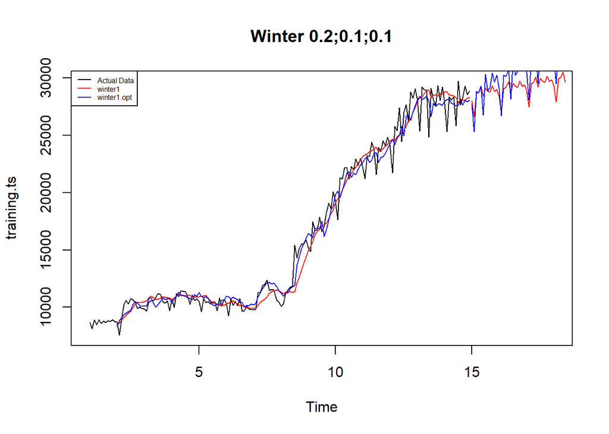

```r
#Plot time series
plot(training.ts,main="Winter 0.2;0.1;0.1",type="l",col="black",
     xlim=c(1,18),pch=12)
lines(xhat1,type="l",col="red")
lines(xhat1.opt,type="l",col="blue")
lines(forecast1,type="l",col="red")
lines(forecast1.opt,type="l",col="blue")
legend("topleft",c("Actual Data",expression(paste(winter1)),
                   expression(paste(winter1.opt))),cex=0.5,
       col=c("black","red","blue"),lty=1)
```

```r
dev.copy(png, "Plot Perbandingan Metode Winter Aditif.png")
```

```r
dev.off()
```

#### Akurasi Data Latih

```r
#Akurasi data training
SSE1<-winter1$SSE
MSE1<-winter1$SSE/length(training.ts)
RMSE1<-sqrt(MSE1)
akurasi1 <- matrix(c(SSE1,MSE1,RMSE1))
row.names(akurasi1)<- c("SSE", "MSE", "RMSE")
colnames(akurasi1) <- c("Akurasi")
akurasi1
```

```
##           Akurasi
## SSE  1.555717e+08
## MSE  9.260220e+05
## RMSE 9.623004e+02
```

```r
SSE1.opt<-winter1.opt$SSE
MSE1.opt<-winter1.opt$SSE/length(training.ts)
RMSE1.opt<-sqrt(MSE1.opt)
akurasi1.opt <- matrix(c(SSE1.opt,MSE1.opt,RMSE1.opt))
row.names(akurasi1.opt)<- c("SSE1.opt", "MSE1.opt", "RMSE1.opt")
colnames(akurasi1.opt) <- c("Akurasi")
akurasi1.opt
```

```
##                Akurasi
## SSE1.opt  1.050458e+08
## MSE1.opt  6.252726e+05
## RMSE1.opt 7.907418e+02
```

```r
akurasi1.train = data.frame(Model_Winter = c("Winter 1","Winter1 optimal"),Nilai_SSE=c(SSE1,SSE1.opt),Nilai_MSE=c(MSE1,MSE1.opt),Nilai_RMSE=c(RMSE1,RMSE1.opt))
akurasi1.train
```

```
##      Model_Winter Nilai_SSE Nilai_MSE Nilai_RMSE
## 1        Winter 1 155571694  926022.0   962.3004
## 2 Winter1 optimal 105045802  625272.6   790.7418
```

#### Akurasi Data Uji

```r
#Akurasi Data Testing
forecast1<-data.frame(forecast1)
testing.ts<-data.frame(testing.ts)
selisih1<-forecast1-testing.ts
SSEtesting1<-sum(selisih1^2)
MSEtesting1<-SSEtesting1/length(testing.ts)

forecast1.opt<-data.frame(forecast1.opt)
selisih1.opt<-forecast1.opt-testing.ts
SSEtesting1.opt<-sum(selisih1.opt^2)
MSEtesting1.opt<-SSEtesting1.opt/length(testing.ts)

akurasi1.test = data.frame(Model_Winter = c("Winter 1","Winter1 optimal"), Nilai_SSE=c(SSEtesting1,SSEtesting1.opt), Nilai_MSE=c(MSEtesting1,MSEtesting1.opt))
akurasi1.test
```

```
##      Model_Winter   Nilai_SSE   Nilai_MSE
## 1        Winter 1  9744975264  9744975264
## 2 Winter1 optimal 11220474839 11220474839
```

### Winter Multiplikatif

Model multiplikatif digunakan cocok digunakan jika plot data asli menunjukkan fluktuasi musiman yang bervariasi.

#### Pemulusan

```r
#Pemulusan dengan winter multiplikatif
winter2 <- HoltWinters(training.ts,alpha=0.2,beta=0.1,gamma=0.3,seasonal = "multiplicative")
winter2$fitted
```

```
##             xhat     level      trend    season
## Jan  2  8145.650  8397.958 115.722319 0.9567719
## Feb  2  7142.809  8634.367 127.791036 0.8151884
## Mar  2  8601.543  8865.985 138.173681 0.9552857
## Apr  2  9876.830  9089.464 146.704253 1.0693645
## May  2 10402.406  9297.732 152.860616 1.1007147
## Jun  2 10218.606  9487.949 156.596261 1.0595219
## Jul  2  9978.888  9661.797 158.321445 1.0161678
## Aug  2 10190.116  9974.052 173.714801 1.0041732
## Sep  2 10694.509 10239.959 182.934009 1.0260596
## Oct  2 10657.525 10374.453 178.090055 1.0099484
## Nov  2 10648.285 10399.957 162.831364 1.0080942
## Dec  2 10365.425 10440.322 150.584784 0.9787099
## Jan  3 10346.666 10494.775 140.971615 0.9728198
## Feb  3  8819.027 10537.339 131.130827 0.8266440
## Mar  3 10652.448 10875.082 151.792033 0.9660442
## Apr  3 12004.021 10988.895 147.994114 1.0778612
## May  3 12154.622 10869.318 121.237036 1.1059152
## Jun  3 11466.240 10706.153  92.796839 1.0617921
## Jul  3 11135.094 10677.977  80.699564 1.0349873
## Aug  3 11017.505 10772.379  82.069744 1.0150221
## Sep  3 11183.302 10876.417  84.266639 1.0203106
## Oct  3 10808.191 10823.020  70.500196 0.9921670
## Nov  3 10802.598 10807.004  61.848614 0.9939042
## Dec  3 10533.343 10824.664  57.429720 0.9679519
## Jan  4 10339.635 10708.873  40.107718 0.9619177
## Feb  4  9189.046 10820.997  47.309271 0.8454902
## Mar  4 10700.231 11056.352  66.113844 0.9620377
## Apr  4 11819.445 11223.245  76.191812 1.0460207
## May  4 11974.209 11125.168  58.764914 1.0706617
## Jun  4 11661.872 11085.637  48.935313 1.0473570
## Jul  4 11531.953 11081.511  43.629158 1.0365670
## Aug  4 11324.301 11089.647  40.079881 1.0174824
## Sep  4 11131.629 11047.308  31.837952 1.0047371
## Oct  4 10726.850 10902.258  14.149174 0.9826356
## Nov  4 10890.455 10989.710  21.479459 0.9890353
## Dec  4 10408.794 10950.836  15.444180 0.9491636
## Jan  5 10721.862 11035.648  22.380943 0.9695998
## Feb  5  9524.177 11020.723  18.650284 0.8627462
## Mar  5 10781.834 11066.454  21.358440 0.9724041
```

[output cut: 102 more lines]

```
## Oct 13 29814.245 28242.007 118.234701 1.0512691
## Nov 13 28757.292 28265.643 108.774796 1.0134936
## Dec 13 29035.624 28234.645  94.797567 1.0249275
## Jan 14 27910.321 28361.713  98.024641 0.9806949
## Feb 14 25623.109 28430.714  95.122181 0.8982422
## Mar 14 29215.685 28455.006  88.039253 1.0235658
## Apr 14 28603.251 28377.021  71.436796 1.0054412
## May 14 29321.558 28340.794  60.670366 1.0323960
## Jun 14 27346.524 28216.930  42.217015 0.9677052
## Jul 14 28572.408 27942.827  10.584985 1.0221438
## Aug 14 28790.375 28176.784  32.922196 1.0205840
## Sep 14 28003.885 27986.428  10.594301 1.0002451
## Oct 14 29391.873 28054.831  16.375194 1.0470470
## Nov 14 28273.375 28049.455  14.200068 1.0074730
## Dec 14 28881.968 28121.150  19.949600 1.0263269
```

```r
xhat2 <- winter2$fitted[,2]

winter2.opt<- HoltWinters(training.ts, alpha= NULL,  beta = NULL, gamma = NULL, seasonal = "multiplicative")
winter2.opt$fitted
```

```
##             xhat     level    trend    season
## Jan  2  8145.650  8397.958 115.7223 0.9567719
## Feb  2  7303.067  8843.026 115.7223 0.8151884
## Mar  2  8836.878  9134.786 115.7223 0.9552857
## Apr  2 10121.074  9348.847 115.7223 1.0693645
## May  2 10592.878  9507.914 115.7223 1.1007147
## Jun  2 10327.008  9631.135 115.7223 1.0595219
## Jul  2 10013.133  9738.096 115.7223 1.0161678
## Aug  2 10414.501 10255.498 115.7223 1.0041732
## Sep  2 10893.233 10500.848 115.7223 1.0260596
## Oct  2 10598.802 10378.677 115.7223 1.0099484
## Nov  2 10308.225 10109.736 115.7223 1.0080942
## Dec  2  9974.121 10075.368 115.7223 0.9787099
## Jan  3 10117.608 10146.968 115.7223 0.9858631
## Feb  3  8479.049 10124.505 115.7223 0.8280137
## Mar  3 10736.103 11027.218 115.7223 0.9634892
## Apr  3 11922.021 10991.636 115.7223 1.0733444
## May  3 11599.572 10415.803 115.7223 1.1014143
## Jun  3 10738.847 10027.287 115.7223 1.0587436
## Jul  3 10803.963 10186.906 115.7223 1.0486609
## Aug  3 10779.498 10511.872 115.7223 1.0142933
## Sep  3 11006.359 10815.659 115.7223 1.0068590
## Oct  3 10531.757 10646.602 115.7223 0.9785764
## Nov  3 10747.887 10677.127 115.7223 0.9958341
## Dec  3 10550.295 10702.480 115.7223 0.9752355
## Jan  4 10192.606 10339.542 115.7223 0.9748779
## Feb  4  9504.954 10731.490 115.7223 0.8762577
## Mar  4 10728.218 11145.590 115.7223 0.9526614
## Apr  4 11815.219 11523.005 115.7223 1.0151641
## May  4 11899.855 11150.978 115.7223 1.0561970
## Jun  4 11845.383 11033.207 115.7223 1.0624682
## Jul  4 11752.184 10911.919 115.7223 1.0657024
## Aug  4 11250.152 10820.645 115.7223 1.0286919
## Sep  4 10704.538 10753.243 115.7223 0.9848719
## Oct  4 10430.671 10613.196 115.7223 0.9722016
## Nov  4 11089.409 11097.374 115.7223 0.9889693
## Dec  4 10373.114 10938.591 115.7223 0.9383770
## Jan  5 11329.493 11266.541 115.7223 0.9953638
## Feb  5  9908.268 10949.912 115.7223 0.8954090
## Mar  5 10691.469 10902.725 115.7223 0.9703245
```

[output cut: 102 more lines]

```
## Oct 13 29716.112 27876.605 115.7223 1.0615806
## Nov 13 28353.286 27787.134 115.7223 1.0161428
## Dec 13 28492.063 27739.420 115.7223 1.0228655
## Jan 14 27456.743 28233.419 115.7223 0.9685212
## Feb 14 24945.312 28524.542 115.7223 0.8709875
## Mar 14 29152.658 28865.654 115.7223 1.0059101
## Apr 14 28453.507 28554.554 115.7223 0.9924393
## May 14 29072.336 28454.970 115.7223 1.0175580
## Jun 14 26018.159 28193.446 115.7223 0.9190718
## Jul 14 29107.501 28189.118 115.7223 1.0283577
## Aug 14 29030.838 28626.730 115.7223 1.0100334
## Sep 14 27852.829 27996.840 115.7223 0.9907610
## Oct 14 30041.800 28355.041 115.7223 1.0551807
## Nov 14 28508.712 28075.694 115.7223 1.0112550
## Dec 14 29301.402 28220.716 115.7223 1.0340538
```

```r
xhat2.opt <- winter2.opt$fitted[,2]
```

#### Peramalan

```r
#Forecast
forecast2 <- predict(winter2, n.ahead = 42)
forecast2.opt <- predict(winter2.opt, n.ahead = 42)
```

#### Plot Deret Waktu

[figure not shown]

```r
#Plot time series
plot(training.ts,main="Winter 0.2;0.1;0.1",type="l",col="black",
     xlim=c(1,18),pch=12)
lines(xhat2,type="l",col="red")
lines(xhat2.opt,type="l",col="blue")
lines(forecast2,type="l",col="red")
lines(forecast2.opt,type="l",col="blue")
legend("topleft",c("Actual Data",expression(paste(winter2)),
                   expression(paste(winter2.opt))),cex=0.5,
       col=c("black","red","blue"),lty=1)
```

```r
dev.copy(png, "Plot Perbandingan Metode Winter Multiplikatif.png")
```

```r
dev.off()
```

#### Akurasi Data Latih

```r
#Akurasi data training
SSE2<-winter2$SSE
MSE2<-winter2$SSE/length(training.ts)
RMSE2<-sqrt(MSE2)
akurasi1 <- matrix(c(SSE2,MSE2,RMSE2))
row.names(akurasi1)<- c("SSE2", "MSE2", "RMSE2")
colnames(akurasi1) <- c("Akurasi lamda=0.2")
akurasi1
```

```
##       Akurasi lamda=0.2
## SSE2       1.558015e+08
## MSE2       9.273897e+05
## RMSE2      9.630108e+02
```

```r
SSE2.opt<-winter2.opt$SSE
MSE2.opt<-winter2.opt$SSE/length(training.ts)
RMSE2.opt<-sqrt(MSE2.opt)
akurasi1.opt <- matrix(c(SSE2.opt,MSE2.opt,RMSE2.opt))
row.names(akurasi1.opt)<- c("SSE2.opt", "MSE2.opt", "RMSE2.opt")
colnames(akurasi1.opt) <- c("Akurasi")
akurasi1.opt
```

```
##                Akurasi
## SSE2.opt  1.179291e+08
## MSE2.opt  7.019589e+05
## RMSE2.opt 8.378298e+02
```

```r
akurasi2.train = data.frame(Model_Winter = c("Winter 1","winter2 optimal"),Nilai_SSE=c(SSE2,SSE2.opt),Nilai_MSE=c(MSE2,MSE2.opt),Nilai_RMSE=c(RMSE2,RMSE2.opt))
akurasi2.train
```

```
##      Model_Winter Nilai_SSE Nilai_MSE Nilai_RMSE
## 1        Winter 1 155801473  927389.7   963.0108
## 2 winter2 optimal 117929088  701958.9   837.8298
```

#### Akurasi Data Uji

```r
#Akurasi Data Testing
forecast2<-data.frame(forecast2)
testing.ts<-data.frame(testing.ts)
selisih2<-forecast2-testing.ts
SSEtesting2<-sum(selisih2^2)
MSEtesting2<-SSEtesting2/length(testing.ts)

forecast2.opt<-data.frame(forecast2.opt)
selisih2.opt<-forecast2.opt-testing.ts
SSEtesting2.opt<-sum(selisih2.opt^2)
MSEtesting2.opt<-SSEtesting2.opt/length(testing.ts)
MSEtesting2.opt
```

```
## [1] 10842808586
```

```r
akurasi2.train = data.frame(Model_Winter = c("Winter 1","winter2 optimal"),Nilai_SSE=c(SSE2,SSE2.opt),Nilai_MSE=c(MSE2,MSE2.opt))
akurasi2.train
```

```
##      Model_Winter Nilai_SSE Nilai_MSE
## 1        Winter 1 155801473  927389.7
## 2 winter2 optimal 117929088  701958.9
```

### Perbandingan Nilai Akurasi Data Uji Semua Metode

```r
akurasi_test.sma
```

```
##      Akurasi m = 4
## SSE   9.348570e+09
## MSE   2.225850e+08
## MAPE  1.325361e+02
```

```r
akurasi_test.dma
```

```
##      Akurasi m = 4
## SSE   1.505059e+10
## MSE   3.583473e+08
## MAPE  1.644805e+02
```